# stocks time series

> Stocks rallied Monday afternoon, with the Dow rallying $976$ points during the session, as investors bet that the worst of the credit crisis is over, following a series of global initiatives announced over the last few days.

> That bounce was predicated by the day’s news, with investors breathing a sigh of relief that some specifics were finally released regarding the $\$700$ billion bank bailout.

Let’s hone down on the crisis period:

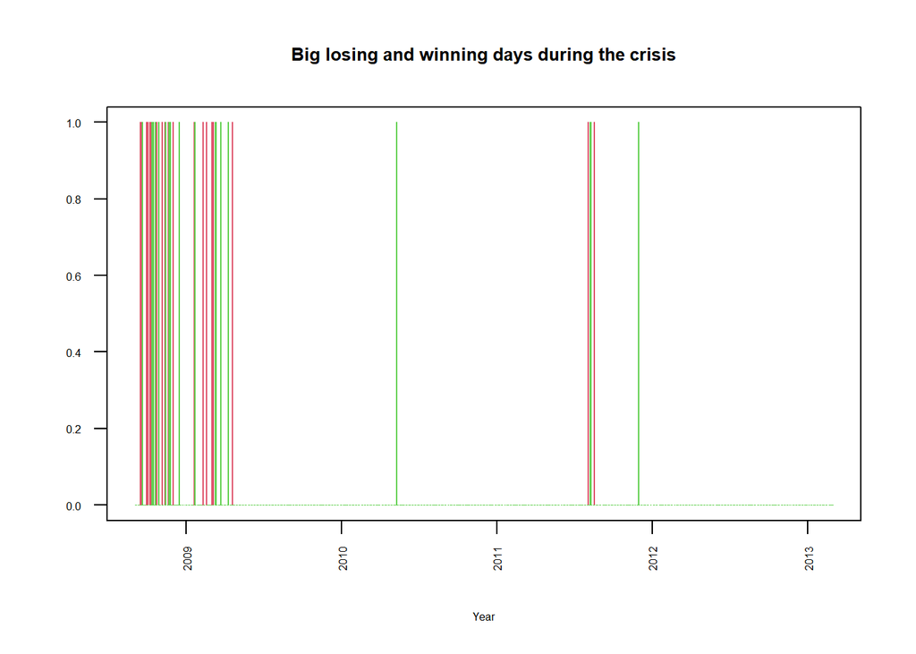

```r
crisis = VTI["2008-09-01/2013-03-01"]
plot(time(crisis), crisis$VTI.InterDay < - 4, col=2, type='h',
     xlab="Year", ylab="",
     cex.axis=.5, cex.main=.8, cex.lab =.5,las=2,
     main  = "Big losing and winning days during the crisis")
points(time(crisis), crisis$VTI.InterDay > 4, col=3, type='h')
```

Between the start of the crisis around September 2008, and the nadir, on March 09, 2009,

> A year later, we know that March 9 was the bottom of a months-long financial panic that wiped away trillions of dollars in assets. But on what now appears to have been the best buying opportunity of a generation, many only wondered how much lower the markets would tumble. (Forbes)

> For Dow, another $12$-year low.

> S&P also finishes at lowest level in more than a decade as Wall Street resumes its retreat on economic worries.

> By Alexandra Twin, CNNMoney.com senior writer Last Updated: March 9, 2009: 6:18 PM ET

there was a loss of

```r
(drop = as.numeric(VTI$VTI.Close["2009-03-09"]) - as.numeric(VTI$VTI.Close["2008-09-10"]))
```

```
## [1] -28.22
```

```r
drop/as.numeric(VTI$VTI.Close["2008-09-10"]) * 100 # In percentage...
```

```
## [1] -45.57493
```

which didn’t recover fully until March 2013, four years later:

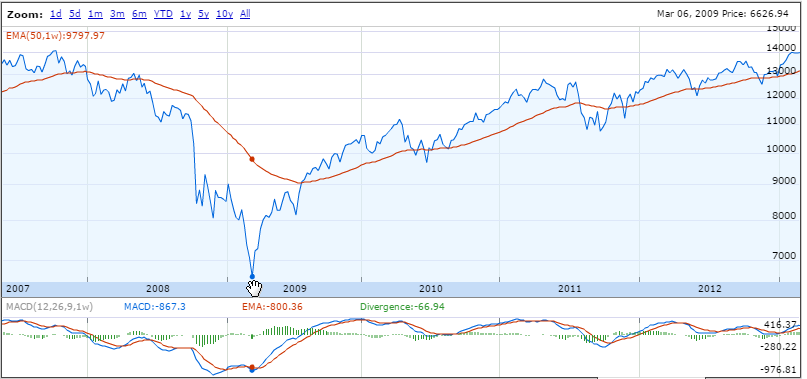

What happened on October 10, 2009? Not much, it was Saturday. And on Monday

```r
VTI["2009-10-12"]
```

```
##            VTI.Open VTI.High VTI.Low VTI.Close VTI.Volume VTI.Adjusted
## 2009-10-12    54.63    54.84   54.38      54.6     868000      43.1978
##            VTI.InterDay
## 2009-10-12    0.3676827
```

not much happened, either… October 14, 2009, perhaps?

```r
VTI["2009-10-14"]
```

```
##            VTI.Open VTI.High VTI.Low VTI.Close VTI.Volume VTI.Adjusted
## 2009-10-14    55.11    55.48   54.87     55.42    1322200     43.84655
##            VTI.InterDay
## 2009-10-14     1.781469
```

Finally, let’s take a look at the fat tails of VTI as representative of the market, and as compared to the normal distribution:

[figure not shown]

```r
hist(VTI$VTI.InterDay,main="INTERDAY VTI % CHANGES: FAT TAILS",sub="fitted normal (in purple); pdf estimate (in blue)",xlab = "PERCENTAGE CHANGE FROM DAY TO DAY",
     ylab = "FREQUENCY", prob = TRUE, col ="coral", ylim=c(0,0.5),
     xlim=c(-4,4), cex.main=.9, cex.sub=.8, cex.lab=.7, border=F,
     breaks = 33)

#Add density estimate
lines(density(VTI$VTI.InterDay,adjust=7),col="darkred",lwd=2) #Prettier, adjusted pdf estimate
sd = sd(VTI$VTI.InterDay)
m = mean(VTI$VTI.InterDay)
curve(dnorm(x,mean=m,sd=sd),col="grey60",lwd=2,add=T,yaxt="n")
lines(density(VTI$VTI.InterDay,adjust=7),col="darkred",lwd=2) #Prettier, adjusted pdf estimate
```

But let’s objectivize the lack of normality:

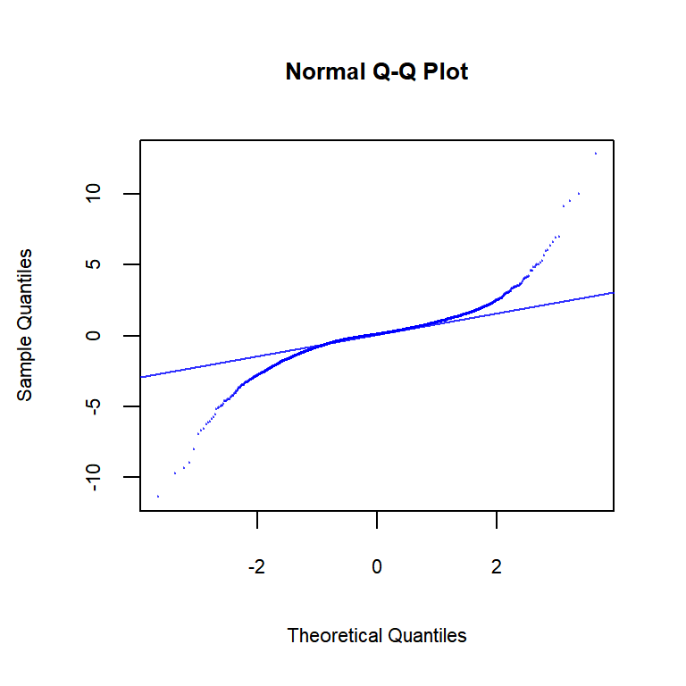

```r
qqnorm(VTI$VTI.InterDay, pch=19, cex=.1, col=rgb(0,0,1,0.5), cex.main=.8, cex.lab=.7, cex.axis=.7)
qqline(VTI$VTI.InterDay, col=rgb(0,0,1,0.8))
```

```r
shapiro.test(as.vector(VTI$VTI.InterDay))
```

```
##
##  Shapiro-Wilk normality test
##
## data:  as.vector(VTI$VTI.InterDay)
## W = 0.87681, p-value < 2.2e-16
```

[Home Page](http://rinterested.github.io/statistics/index.html)

**NOTE: These are tentative notes on different topics for personal use - expect mistakes and misunderstandings.**